**R Markdown Demo >**

## R Markdown

> R Markdown keeps your plots, output, and analysis all in one place. No more outdated charts and data floating around.

> You are currently reading the output of an R Markdown document. Markdown is a simple syntax for authoring HTML, PDF, and Word documents. For more details on using R Markdown see http://rmarkdown.rstudio.com.

## A motivational example

> [Scary changes: A Reproducible workflow](https://youtu.be/s3JldKoA0zw)

## Markdown basics

> https://slides.djnavarro.net/starting-rmarkdown/#17

### The YAML

The YAML (“Yet Another Markup Language”) is the document settings stored atop the R Markdown document, bounded on each end by `---`. When you first create a new `.Rmd` the YAML will look something like this:

```
---
title: "Document title"
author: "Author"
date: "MM/DD/YYYY"
output: html_document
---
```

## Demo time

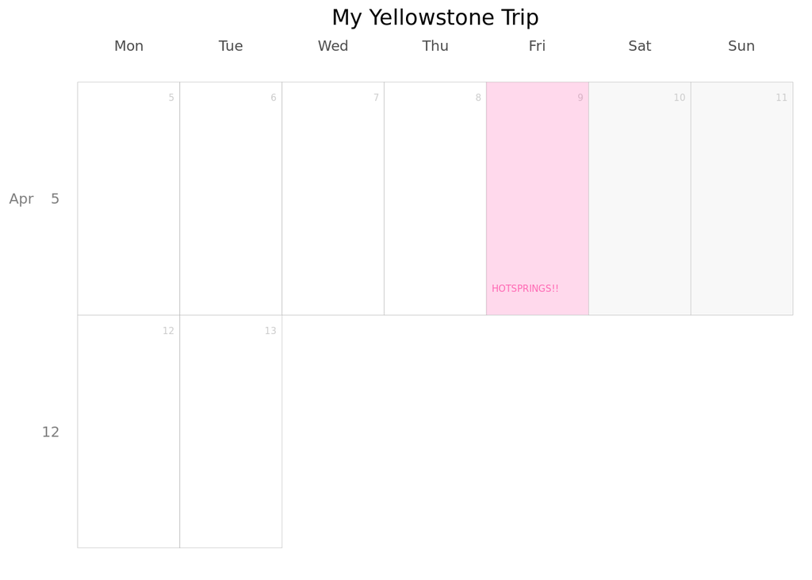

```r
library(tidyverse)
library(ggweekly) #remotes::install_github("gadenbuie/ggweekly")

start <- "2021-04-05"
end <- as.Date(start) + 8

ggweek_planner(
  start_day = start,
  end_day = end,
  highlight_days = tibble(day = "2021-04-09",
                          label = "HOTSPRINGS!!",
                          color = "hotpink",
                          fill  = "hotpink")
) +
  labs(title = "My Yellowstone Trip")
```

### Code chunk options

Chunk options are options designated in the code chunk header that determine what appears or does not appear in the final document.

For more information on code chunk options in R Markdown, see Chapter 11 in the [R Markdown Cookbook](https://bookdown.org/yihui/rmarkdown-cookbook/chunk-options.html).

Here are some common chunk options:

- `echo = FALSE`: do not show the code in the knitted document
- `include = FALSE`: do not include code or any outputs in knitted document
- `message = FALSE`: suppress messages when knit
- `warning = FALSE`: suppress warnings when knit
- `eval = FALSE`: do not evaluate this code

### Customization

Let’s make some changes to the YAML in our .Rmd to change the output document.

**Let’s try the following:**

- `toc: true`: add a table of contents based on header hierarchies
- `toc_float: true`: make it a floating TOC
- `number_sections: true`: add numbered sections based on header hierarchy
- `theme: _____`: add a bootstrap theme
- `code_folding: hide`: code is default hidden, but available if the reader clicks on the ‘Code’ button created

To add options to the YAML, add them as “children” under the `html_document:` section.

**Beware of spacing here**. You add 2 spaces of indentation for each new sub-level in the YAML hierarchy.

```
---
title: "Level up in R Markdown"
subtitle: "UCSB QMSS seminar series (February 2021)"
author: "Allison Horst"
output:
  html_document:
    toc: true
    toc_float: true
    number_sections: true
    theme: flatly
    code_folding: hide
---
```

#### For more bootstrap themes visit: https://bootswatch.com/3/

### More Markdown resources

[figure not shown]

- [The R Markdown Cookbook](https://bookdown.org/yihui/rmarkdown-cookbook/) by Yihui Xie, Christophe Dervieux, Emily Riederer
- [R Markdown: the Definitive Guide](https://bookdown.org/yihui/rmarkdown/) by Yihui Xie, J. J. Allaire, Garrett Grolemund
- [RStudio’s R Markdown site](https://rmarkdown.rstudio.com/)
- [R Markdown Reference Guide](https://www.rstudio.com/wp-content/uploads/2015/03/rmarkdown-reference.pdf)
- [RStudio’s R Markdown lesson series](https://rmarkdown.rstudio.com/lesson-1.html)
- [Alison Hill’s Advanced R Markdown workshop](https://alison.rbind.io/project/advanced-r-markdown/)